# Demographics and reproductive biology of H. schistosus from bycatch on the west coast of India

Analysis for Manuscript

# Introduction

This the code for analysis and supplementary figures for the manuscript. The manuscript is currently under review.

```r
#Required libraries

require(tidyverse)
require(lubridate)
require(viridis)

# Importing data

snakes = read.csv("./Data/Sea-snakes_fish-dep_mastersheet_250420.csv")
embryos = read.csv("./Data/Sea snake_embryo data_mastersheet.csv")

snakes <- snakes%>%
  mutate(Year = as.factor(Year))%>%
  filter(Species == "Hydrophis curtus" | Species == "Hydrophis schistosus")%>%
  droplevels()

HS <- snakes%>%
  filter(Species == "Hydrophis schistosus")%>% # filtering out other snakes from bycatch data
  mutate(Year = as.factor(Year))

# function to calculate mcfadden's r2

mcfadden <- function(x){

  r2 <- 1 - (x$deviance/x$null.deviance)

}

# sampling years
years <- data.frame(Year = factor(c(2016:2019)))
```

## Sample size

The number of snakes (N) sampled from bycatch of trawlers, shore seines and gillnetss.

```r
snakes%>%
  group_by(Species)%>%
  count(name = "N")
```

| Species | N |
| --- | --- |
| Hydrophis curtus | 282 |
| Hydrophis schistosus | 967 |

The number of snakes sampled in each year:

```r
n.yr <- snakes%>%
  group_by(Species, Year)%>%
  count(name = "N")

n.yr%>%
  spread(Year, N)
```

| Species | 2016 | 2017 | 2018 | 2019 |
| --- | --- | --- | --- | --- |
| Hydrophis curtus | 75 | 38 | 123 | 46 |
| Hydrophis schistosus | 178 | 215 | 521 | 53 |

The number of trips (n) and fishing effort (haul-hours) sampled for sea snakes in the current study.

```r
snakes%>%
  filter(Gear.Type != "")%>%
  select(Date, Boat.ID, Gear.Type, No..of.Hauls, Average.Haul.Duration..Hours., Tow.duration.hours)%>%
  distinct()%>%
  # Calculating tow duration
  mutate(Tow.duration.hours = case_when(!is.na(Tow.duration.hours) ~ Tow.duration.hours,
                                        is.na(Tow.duration.hours) ~ No..of.Hauls*Average.Haul.Duration..Hours.))%>%
  group_by(Gear.Type)%>%
  summarise(n = n(), # counting number of trips sampled
            haul.hours = sum(Tow.duration.hours, na.rm = T)) # total fishing effort
```

| Gear.Type | n | haul.hours |
| --- | --- | --- |
| GillNet | 439 | 585.2133 |
| Rampan | 46 | 190.4500 |
| Trawler | 77 | 292.6600 |

# Demographics of *H. schistosus* across time

## Age structure

```r
# calculating the mean SVL across years

age.yr <- snakes%>%
  group_by(Species, Year)%>%
  summarise(N = n(),
            mean = mean(Snout.to.Vent..cm., na.rm = T))

# SVL cut off for age classes

maturtity <- snakes%>%
  group_by(Species)%>%
  count()%>%
  mutate(juv = 35,
         adult = ifelse(Species == "Hydrophis curtus", 54, 65))
```

### Distribution fo SVL across years

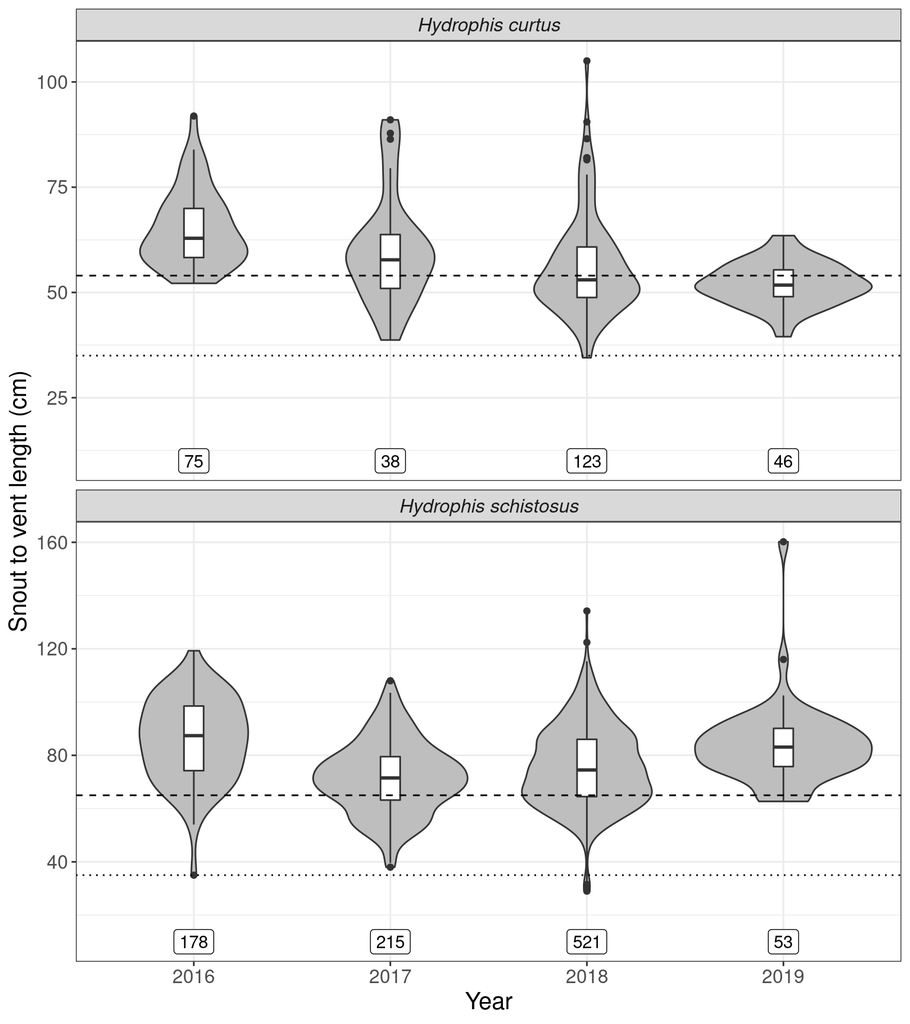

```r
# plotting distribution of SVL across years

snakes%>%
  filter(Snout.to.Vent..cm. > 20)%>%
  ggplot(aes(Year, Snout.to.Vent..cm.))+
  geom_violin(fill = "grey")+
  geom_boxplot(width = 0.1)+
  geom_hline(data = maturtity, aes(yintercept = adult), linetype = "dashed")+
  geom_hline(data = maturtity, aes(yintercept = juv), linetype = "dotted")+
  #stat_summary(fun.data = "mean_sdl", geom = "pointrange", size = 1)+
  geom_label(data = age.yr, aes(Year, 10, label = N))+
  facet_wrap(~Species, ncol = 1, scales = "free_y")+
  labs(y = "Snout to vent length (cm)")+
  theme(strip.text = element_text(face = "italic"))
```

```r
ggsave(last_plot(), filename = "./Figures/figure1.tiff", height = 9, width = 8)
```

Linear model for change in SVL of each species across years:

```r
library(car)
require(broom)

snakes%>%
  group_by(Species)%>%
  select(Year, Snout.to.Vent..cm.)%>%
  nest()%>%
  mutate(mod = map(data, ~lm(Snout.to.Vent..cm. ~ Year, data = .)),
          sumr = map(mod, broom::tidy),
         stat = map(mod, glance))%>%
  select(sumr, stat)%>%
  unnest()%>%
  select(c(Species:r.squared))
```

| Species | term | estimate | std.error | statistic | p.value | r.squared |
| --- | --- | --- | --- | --- | --- | --- |
| Hydrophis schistosus | (Intercept) | 85.598303 | 1.850695 | 46.2519793 | 0.0000000 | 0.0689121 |
| Hydrophis schistosus | Year2017 | -13.996389 | 2.122893 | -6.5930743 | 0.0000000 | 0.0689121 |
| Hydrophis schistosus | Year2018 | -10.158177 | 1.974836 | -5.1438083 | 0.0000003 | 0.0689121 |
| Hydrophis schistosus | Year2019 | -1.732303 | 2.818894 | -0.6145327 | 0.5390387 | 0.0689121 |
| Hydrophis curtus | (Intercept) | 65.043404 | 1.511818 | 43.0233133 | 0.0000000 | 0.1470604 |
| Hydrophis curtus | Year2017 | -5.212154 | 2.405287 | -2.1669571 | 0.0312836 | 0.1470604 |
| Hydrophis curtus | Year2018 | -8.833123 | 1.825449 | -4.8388759 | 0.0000024 | 0.1470604 |
| Hydrophis curtus | Year2019 | -12.998166 | 2.225335 | -5.8409920 | 0.0000000 | 0.1470604 |

ANOVA to test for effect of years:

```r
snakes%>%
  group_by(Species)%>%
  select(Year, Snout.to.Vent..cm.)%>%
  nest()%>%
  mutate(mod = map(data, ~lm(Snout.to.Vent..cm. ~ Year, data = .)),
          stat = map(mod, car::Anova))%>%
  select(stat)%>%
  unnest()
```

| Species | Sum Sq | Df | F value | Pr(>F) |
| --- | --- | --- | --- | --- |
| Hydrophis schistosus | 13334.508 | 3 | 19.66265 | 0e+00 |
| Hydrophis schistosus | 180165.620 | 797 | NA | NA |
| Hydrophis curtus | 4363.959 | 3 | 12.98867 | 1e-07 |
| Hydrophis curtus | 25310.652 | 226 | NA | NA |

Plotting fitted values:

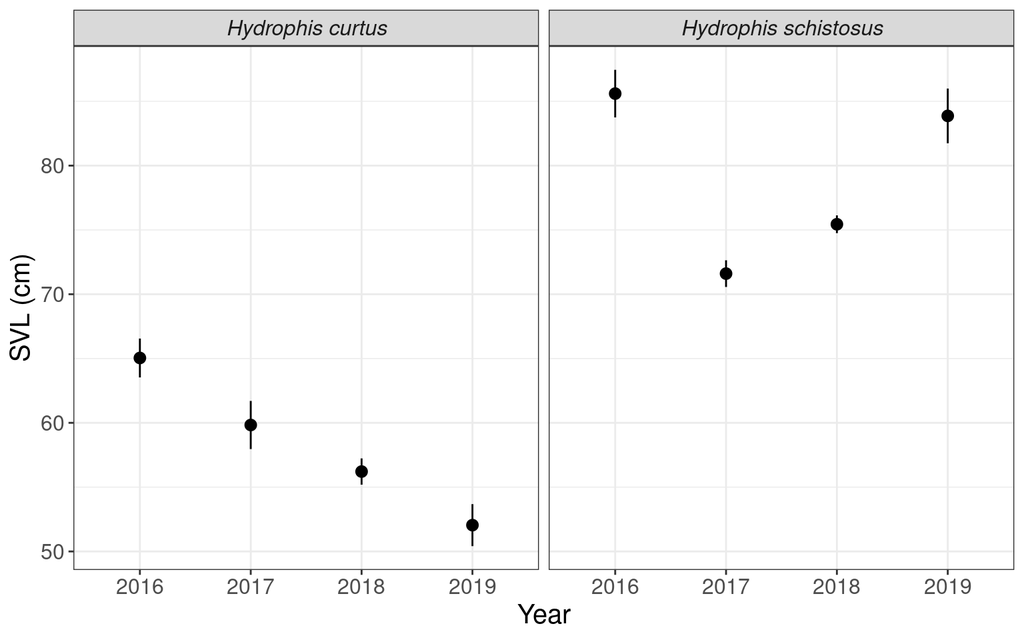

```r
snakes%>%
  group_by(Species)%>%
  select(Year, Snout.to.Vent..cm.)%>%
  nest()%>%
  mutate(mod = map(data, ~lm(Snout.to.Vent..cm. ~ Year, data = .)),
         fit = map(mod, ~predict(., years, se.fit = T)),
         fit = map(fit, ~as.data.frame(.)))%>%
  select(fit)%>%
  unnest()%>%
  mutate(Year = factor(c(2016:2019)))%>%
  ggplot(aes(Year, fit))+
  geom_pointrange(aes(ymin = fit - se.fit, ymax = fit + se.fit))+
  labs(y = "SVL (cm)")+
  facet_wrap(~Species)+
  theme(strip.text = element_text(face = "italic"))
```

There was a significant change in SVL distribution of species across years.

### Proportion of developmental classes across years

```r
snakes%>%
  filter(!is.na(Class))%>%
  group_by(Species)%>%
  # Counting number of individuals in each developmental class
  count(Class)%>%
  complete(Class, fill = list(n = 0))%>%
  # Total number sampled in each year
  mutate(N = sum(n))%>%
  group_by(Species, Class)%>%
  # Proportion of each developmental class
  mutate(p = n/N,
         sd = sqrt(p*(1-p)/N))
```

| Species | Class | n | N | p | sd |
| --- | --- | --- | --- | --- | --- |
| Hydrophis curtus | Adult | 62 | 189 | 0.3280423 | 0.0341511 |
| Hydrophis curtus | Juvenile | 125 | 189 | 0.6613757 | 0.0344233 |
| Hydrophis curtus | Neonate | 2 | 189 | 0.0105820 | 0.0074429 |
| Hydrophis schistosus | Adult | 648 | 761 | 0.8515112 | 0.0128899 |
| Hydrophis schistosus | Juvenile | 105 | 761 | 0.1379763 | 0.0125017 |
| Hydrophis schistosus | Neonate | 8 | 761 | 0.0105125 | 0.0036971 |

### Testing change in proportion of developmental classes across years

Fitting a multinomial logistic model to determine change in age classes across years in each species.

```r
require(nnet)
require(broom)

dev.yr <- snakes%>%
  select(Species, Year, Class)%>%
  filter(!is.na(Class))%>% # removing empty class
  group_by(Species)%>%
  nest()%>%
  mutate(mod = map(data, ~nnet::multinom(Class ~ Year, data = .)),
         null = map(data, ~nnet::multinom(Class ~ 1, data = .)),
         smry = map(mod, ~broom::tidy(., exonentiate = T)),
         # Calculating mc fadden's r2
         r2 = map2_dbl(mod, null, ~ 1 - .x$value/.y$value))
```

```r
dev.yr%>%
  select(smry, r2)%>%
  unnest()
```

| Species | y.level | term | estimate | std.error | statistic | p.value | r2 |
| --- | --- | --- | --- | --- | --- | --- | --- |
| Hydrophis schistosus | Juvenile | (Intercept) | -2.4450606 | 0.7380571 | -3.3128339 | 0.0009236 | 0.0455695 |
| Hydrophis schistosus | Juvenile | Year2017 | 1.1234010 | 0.7573074 | 1.4834147 | 0.1379643 | 0.0455695 |
| Hydrophis schistosus | Juvenile | Year2018 | 0.5064641 | 0.7510767 | 0.6743174 | 0.5001096 | 0.0455695 |
| Hydrophis schistosus | Juvenile | Year2019 | -13.3315259 | 377.0158759 | -0.0353606 | 0.9717922 | 0.0455695 |
| Hydrophis schistosus | Neonate | (Intercept) | -3.1352560 | 1.0212895 | -3.0698995 | 0.0021413 | 0.0455695 |
| Hydrophis schistosus | Neonate | Year2017 | -14.5022162 | 526.2494814 | -0.0275577 | 0.9780149 | 0.0455695 |
| Hydrophis schistosus | Neonate | Year2018 | -0.9347455 | 1.0900891 | -0.8574946 | 0.3911716 | 0.0455695 |
| Hydrophis schistosus | Neonate | Year2019 | -8.7344420 | 53.4649902 | -0.1633675 | 0.8702291 | 0.0455695 |
| Hydrophis curtus | Juvenile | (Intercept) | -1.9386218 | 1.0661369 | -1.8183610 | 0.0690090 | 0.0724193 |
| Hydrophis curtus | Juvenile | Year2017 | 2.7268690 | 1.1322946 | 2.4082681 | 0.0160284 | 0.0724193 |
| Hydrophis curtus | Juvenile | Year2018 | 2.5058458 | 1.0853066 | 2.3088829 | 0.0209501 | 0.0724193 |
| Hydrophis curtus | Juvenile | Year2019 | 3.5480223 | 1.1437099 | 3.1022049 | 0.0019208 | 0.0724193 |
| Hydrophis curtus | Neonate | (Intercept) | -11.1507510 | 99.7723289 | -0.1117620 | 0.9110121 | 0.0724193 |
| Hydrophis curtus | Neonate | Year2017 | -2.2749071 | 278.6764080 | -0.0081633 | 0.9934867 | 0.0724193 |
| Hydrophis curtus | Neonate | Year2018 | 8.2062502 | 99.7749668 | 0.0822476 | 0.9344498 | 0.0724193 |
| Hydrophis curtus | Neonate | Year2019 | -3.4778373 | 576.2501607 | -0.0060353 | 0.9951846 | 0.0724193 |

ANOVA to test for effect of years:

```r
dev.yr%>%
  mutate(stat = map(mod, car::Anova))%>%
  select(stat)%>%
  unnest()
```

| Species | LR Chisq | Df | Pr(>Chisq) |
| --- | --- | --- | --- |
| Hydrophis schistosus | 31.76867 | 6 | 0.0000181 |
| Hydrophis curtus | 18.81199 | 6 | 0.0044932 |

Plotting fitted estimates of proportions:

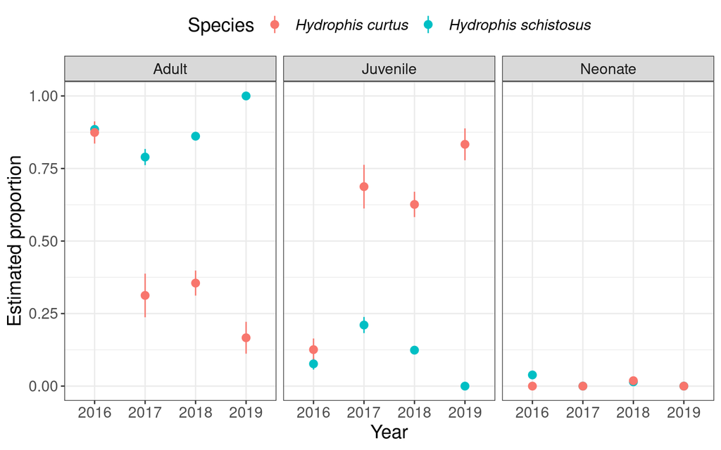

```r
dev.yr%>%
  mutate(fit = map(mod, ~data.frame(predict(., years, "probs"))))%>%
  select(fit)%>%
  unnest()%>%
  mutate(Year = factor(c(2016:2019)))%>% # adding years variable
  left_join(n.yr, by = c("Species", "Year"))%>% # getting sample size in each year
  gather(c(Adult, Juvenile, Neonate), key = "Class", value = "p.hat")%>%
  mutate(se = sqrt(p.hat*(1-p.hat)/N))%>% # caluclating standard error
  # Plotting
  ggplot(aes(Year, p.hat, color = Species))+
  geom_pointrange(aes(ymin = p.hat-se, ymax = p.hat+se))+
  labs(y = "Estimated proportion")+
  facet_wrap(~Class)+
  theme(legend.text = element_text(face = "italic"))
```

The proportion of *H. curtus* juveniles increases significantly between 2016 and 2018

### Change in SVL distribution over months

```r
month.svl <- HS%>%
  filter(Year == "2018", # data not sufficient for other years
         Snout.to.Vent..cm. > 20)%>% # removing erroneous data
  mutate(Month = factor(Month, levels = month.name))%>%
  complete(Month)%>%
  group_by(Month)%>%
  # Calculating mean SVL in each month
  summarise(mean.SVL = mean(Snout.to.Vent..cm., na.rm = T))

# Month of observed births

births <- data.frame(Species = "Hydrophis schistosus", Month = "April")
```

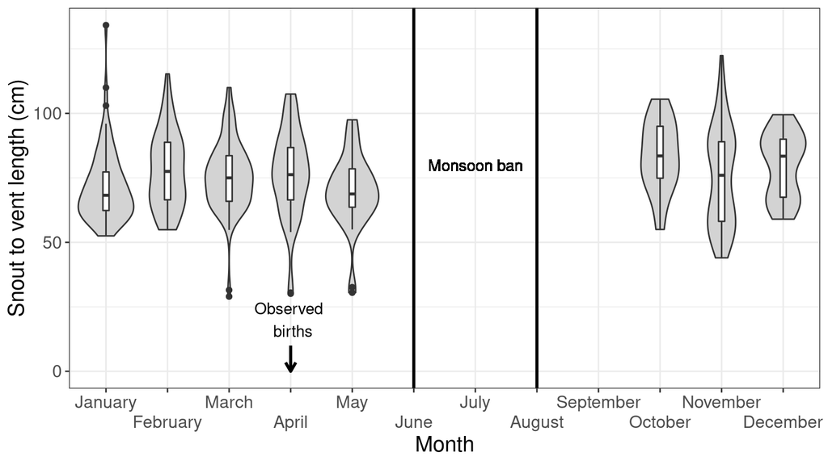

```r
# plotting distribution of SVL across months

HS%>%
  filter(Year == "2018", # data not sufficient for other years
         Snout.to.Vent..cm. > 20)%>% # removing erroneous data
  mutate(Month = factor(Month, levels = month.name))%>%
  complete(nesting(Species), Month)%>%
  droplevels()%>%
  ggplot(aes(Month, Snout.to.Vent..cm.))+
  geom_violin(fill = "light grey")+
  #geom_point(data = month.svl, aes(x = Month, y = mean.SVL), size = 3)+
  geom_boxplot(width = 0.1)+
  geom_segment(data = births, aes(x = Month, xend = Month, y = 0 , yend = 10), #marking births
               arrow = arrow(length = unit(0.25, "cm"), ends = "first"), size = 1)+
  geom_text(data = births, aes(x = Month, y = 20, label = paste("Observed \n births")))+
  geom_vline(aes(xintercept = "June"), size = 1)+#start of the monsoon ban
  geom_vline(aes(xintercept = "August"), size = 1)+#end of the monsoon ban
  geom_text(aes(x = "July", y = 80, label = "Monsoon ban"))+
  scale_x_discrete(guide = guide_axis(n.dodge = 2))+
  labs(y = "Snout to vent length (cm)")
```

Proportion of neonates increases in March to May. Birth and neonates were observed around the same time.

### Proportion of neonates in each month of 2018

```r
snakes%>%
  filter(Year == "2018", # data not sufficient for other years
         Snout.to.Vent..cm. > 20)%>% # removing erroneous data
  mutate(Month = factor(Month, levels = month.name))%>%
  group_by(Species, Month)%>%
  summarise(p = sum(Snout.to.Vent..cm. < 40)/n(),
            sd = sqrt(p*(1-p)/n()))
```

| Species | Month | p | sd |
| --- | --- | --- | --- |
| Hydrophis curtus | January | 0.0000000 | 0.0000000 |
| Hydrophis curtus | February | 0.0000000 | 0.0000000 |
| Hydrophis curtus | March | 0.5000000 | 0.3535534 |
| Hydrophis curtus | October | 0.0000000 | 0.0000000 |
| Hydrophis curtus | November | 0.0769231 | 0.0522589 |
| Hydrophis curtus | December | 0.0000000 | 0.0000000 |
| Hydrophis schistosus | January | 0.0000000 | 0.0000000 |
| Hydrophis schistosus | February | 0.0000000 | 0.0000000 |
| Hydrophis schistosus | March | 0.0200000 | 0.0140000 |
| Hydrophis schistosus | April | 0.0500000 | 0.0344601 |
| Hydrophis schistosus | May | 0.0555556 | 0.0381769 |
| Hydrophis schistosus | October | 0.0000000 | 0.0000000 |
| Hydrophis schistosus | November | 0.0000000 | 0.0000000 |
| Hydrophis schistosus | December | 0.0000000 | 0.0000000 |

## Sex ratios

### Proportion of females encountered by species

```r
snakes%>%
  group_by(Species)%>%
  filter(Sex == "Male" | Sex == "Female")%>%
  summarise(females = sum(Sex == "Female"),
            N = n(),
            P = females/N,
            sd = sqrt(P*(1-P)/N))
```

| Species | females | N | P | sd |
| --- | --- | --- | --- | --- |
| Hydrophis curtus | 102 | 212 | 0.4811321 | 0.0343157 |
| Hydrophis schistosus | 304 | 618 | 0.4919094 | 0.0201103 |

### Testing equality in sex ratios

```r
# is proportion of females different from 0.5?

snakes%>%
  filter(Sex == "Male" | Sex == "Female")%>%
  group_by(Species)%>%
  summarise(females = sum(Sex == "Female"),
            N = n())%>%
  group_by(Species)%>%
  nest()%>%
  mutate(test = map(data, ~prop.test(.$females, .$N, p = 0.5)), # Z - test for proportion
         sumr = map(test, broom::tidy))%>%
  select(sumr)%>%
  unnest()%>%
  select(-c(method, alternative))
```

| Species | estimate | statistic | p.value | parameter | conf.low | conf.high |
| --- | --- | --- | --- | --- | --- | --- |
| Hydrophis curtus | 0.4811321 | 0.2311321 | 0.6306857 | 1 | 0.4125066 | 0.5504525 |
| Hydrophis schistosus | 0.4919094 | 0.1310680 | 0.7173273 | 1 | 0.4518628 | 0.5320580 |

Sex ratio is not different from 0.5; p = 0.71.

### Testing shifts in sex ratios over years

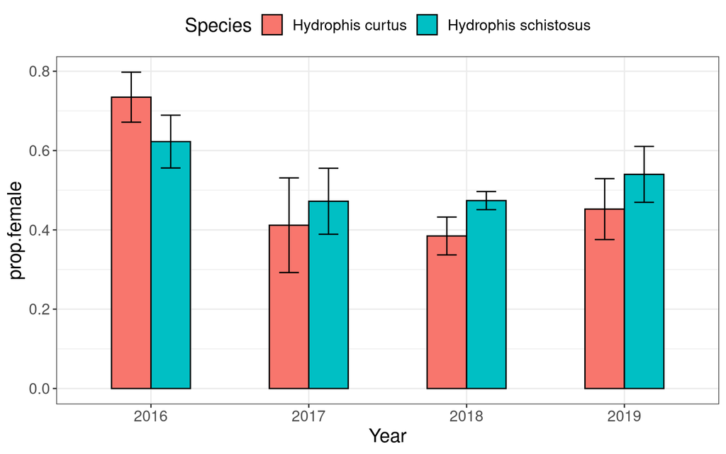

```r
snakes%>%
  filter(Sex == "Male" | Sex == "Female")%>%
  group_by( Species, Year)%>%
  summarise(N = n(),
            females = sum(Sex == "Female"),
            prop.female = females/N,
            sd = sqrt(prop.female*(1-prop.female)/N))%>%
  ggplot(aes(Year, prop.female, fill = Species))+
  geom_col(width = 0.5, col = "black", position = position_dodge())+
  geom_errorbar(aes(ymin = prop.female-sd, ymax = prop.female + sd), position = position_dodge(width = 0.5), width = 0.25)
```

Logistic model to test for change in sex ratios of species across years:

```r
snakes%>%
  select(Species, Year, Sex)%>%
  filter(Sex == "Male" | Sex == "Female")%>% # removing empty sex
  mutate(Sex = factor(Sex, levels = c("Male", "Female")))%>%
  group_by(Species)%>%
  nest()%>%
  mutate(mod = map(data, ~glm(Sex ~ Year, family = binomial, data = .)),
         sumry = map(mod, ~tidy(.)),
         r2 = map_dbl(mod, ~mcfadden(.)))%>%
  select(sumry, r2)%>%
  unnest(sumry)
```

| Species | term | estimate | std.error | statistic | p.value | r2 |
| --- | --- | --- | --- | --- | --- | --- |
| Hydrophis schistosus | (Intercept) | 0.5007753 | 0.2833779 | 1.7671643 | 0.0772007 | 0.0055997 |
| Hydrophis schistosus | Year2017 | -0.6120009 | 0.4379020 | -1.3975752 | 0.1622407 | 0.0055997 |
| Hydrophis schistosus | Year2018 | -0.6052544 | 0.2977861 | -2.0325137 | 0.0421017 | 0.0055997 |
| Hydrophis schistosus | Year2019 | -0.3404326 | 0.4010216 | -0.8489135 | 0.3959294 | 0.0055997 |
| Hydrophis curtus | (Intercept) | 1.0185696 | 0.3235748 | 3.1478639 | 0.0016447 | 0.0593767 |
| Hydrophis curtus | Year2017 | -1.3752445 | 0.5895404 | -2.3327403 | 0.0196618 | 0.0593767 |
| Hydrophis curtus | Year2018 | -1.4885732 | 0.3812161 | -3.9048020 | 0.0000943 | 0.0593767 |
| Hydrophis curtus | Year2019 | -1.2096248 | 0.4481189 | -2.6993392 | 0.0069477 | 0.0593767 |

Plotting predicted values:

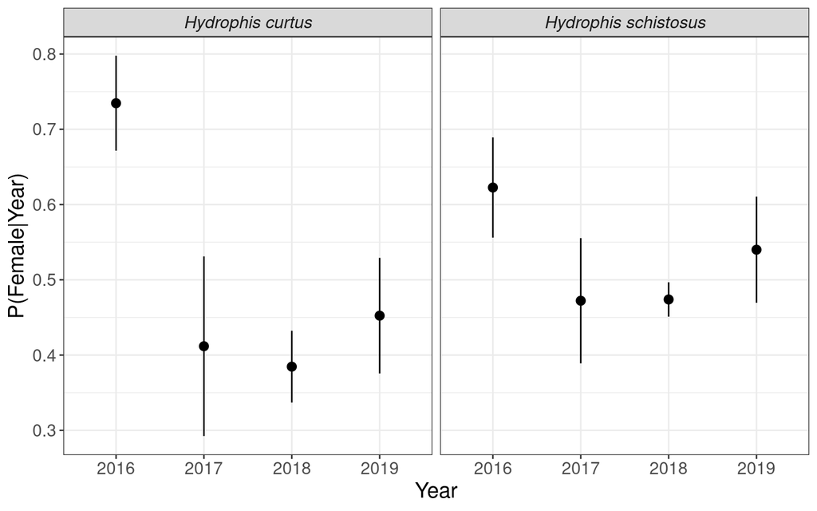

```r
snakes%>%
  select(Species, Year, Sex)%>%
  filter(Sex == "Male" | Sex == "Female")%>% # removing empty sex
  mutate(Sex = factor(Sex, levels = c("Male", "Female")))%>%
  group_by(Species)%>%
  nest()%>%
  mutate(mod = map(data, ~glm(Sex ~ Year, family = "binomial", data = .)),
         fit = map(mod, ~predict(., years, se.fit = T, type = "response")),
         fit = map(fit, ~data.frame(.)))%>%
  select(fit)%>%
  unnest(fit)%>%
  mutate(Year = factor(c(2016:2019)))%>%
  ggplot(aes(Year, fit))+
  geom_pointrange(aes(ymin = fit - se.fit, ymax = fit + se.fit))+
  labs(y = "P(Female|Year)")+
  facet_wrap(~Species)+
  theme(strip.text = element_text(face = "italic"))
```

# Mortality in bycatch

## Overall mortality rate

```r
snakes%>%
  group_by(Species)%>%
  count(Condition.at.encounter..D.A.)%>%
  # Calculating mortality rate
  mutate(N = sum(n),
         prop.dead = n/N,
         sd = sqrt(prop.dead*(1-prop.dead)/N))%>%
  filter(Condition.at.encounter..D.A. == "Dead")%>%
  select(-Condition.at.encounter..D.A.)
```

| Species | n | N | prop.dead | sd |
| --- | --- | --- | --- | --- |
| Hydrophis curtus | 120 | 282 | 0.4255319 | 0.0294425 |
| Hydrophis schistosus | 174 | 967 | 0.1799380 | 0.0123530 |

### Testing difference in mortality across species

Logistic model:

```r
snakes%>%
  filter(Condition.at.encounter..D.A. %in% c("Dead", "Alive"))%>% # removing missing data
  select(Species, Condition.at.encounter..D.A.)%>%
  mutate(Condition = factor(Condition.at.encounter..D.A., levels = c("Alive", "Dead")))%>%
  nest()%>%
  mutate(test = map(data, ~glm(Condition ~ Species, family = "binomial", data = .)),
         sumr = map(test, ~broom::tidy(.)),
         stat = map(test, broom::glance),
         r2 = map(test, ~mcfadden(.)))%>%
  select(sumr, stat, r2)%>%
  unnest()%>%
  select(term:p.value, df.residual, r2)
```

| term | estimate | std.error | statistic | p.value | df.residual | r2 |
| --- | --- | --- | --- | --- | --- | --- |
| (Intercept) | -0.2814125 | 0.1209241 | -2.327182 | 0.0199556 | 1241 | 0.0502489 |
| SpeciesHydrophis schistosus | -1.2315652 | 0.1470904 | -8.372845 | 0.0000000 | 1241 | 0.0502489 |

Fitted probability of mortality:

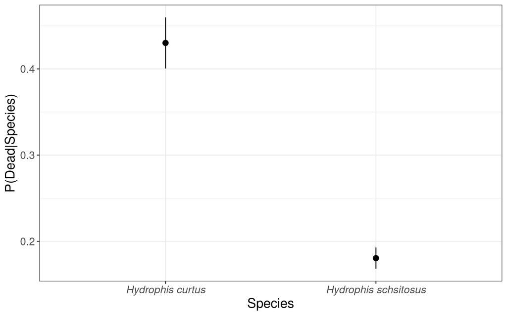

```r
spp = data.frame(Species = c("Hydrophis schistosus", "Hydrophis curtus"))

snakes%>%
  filter(Condition.at.encounter..D.A. %in% c("Dead", "Alive"))%>% # removing missing data
  select(Species, Condition.at.encounter..D.A.)%>%
  mutate(Condition = factor(Condition.at.encounter..D.A., levels = c("Alive", "Dead")))%>%
  nest()%>%
  mutate(mod = map(data, ~glm(Condition ~ Species, family = "binomial", data = .)),
         fit = map(mod, ~predict(., spp, se.fit = T, type = "response")),
         fit = map(fit, ~data.frame(.)))%>%
  select(fit)%>%
  unnest(fit)%>%
  mutate(Species = factor(c("Hydrophis schsitosus", "Hydrophis curtus")))%>%
  ggplot(aes(Species, fit))+
  geom_pointrange(aes(ymin = fit - se.fit, ymax = fit + se.fit))+
  labs(y = "P(Dead|Species)")+
  theme(axis.text.x =  element_text(face = "italic"))
```

*H. curtus* had as significatly higher mortality rate in bycatch than *H. schistosus*

## Mortality rate by age class

Are juveniles more vulnerable to bycatch mortality than adults?

```r
snakes%>%
  filter(!is.na(Class))%>%
  group_by(Species, Class)%>%
  count(Condition.at.encounter..D.A.)%>%
  #calculating mortality rate
  mutate(N = sum(n),
         prop.dead = n/N,
         sd = sqrt(prop.dead*(1-prop.dead)/N))%>%
  filter(Condition.at.encounter..D.A. == "Dead")%>%
  select(-Condition.at.encounter..D.A.)
```

| Species | Class | n | N | prop.dead | sd |
| --- | --- | --- | --- | --- | --- |
| Hydrophis curtus | Adult | 40 | 62 | 0.6451613 | 0.0607650 |
| Hydrophis curtus | Juvenile | 41 | 125 | 0.3280000 | 0.0419920 |
| Hydrophis schistosus | Adult | 138 | 648 | 0.2129630 | 0.0160828 |
| Hydrophis schistosus | Juvenile | 5 | 105 | 0.0476190 | 0.0207827 |
| Hydrophis schistosus | Neonate | 3 | 8 | 0.3750000 | 0.1711633 |

### Testing difference in mortality rates across age classes within species

Logistic model:

```r
snakes%>%
  filter(!is.na(Class),
         Condition.at.encounter..D.A. %in% c("Dead", "Alive"))%>% # removing missing data
  select(Species, Class, Condition.at.encounter..D.A.)%>%
  mutate(Condition = factor(Condition.at.encounter..D.A., levels = c("Alive", "Dead")))%>%
  group_by(Species)%>%
  nest()%>%
  mutate(test = map(data, ~glm(Condition ~ Class, family = "binomial", data = .)),
         sumr = map(test, ~broom::tidy(.)),
         stat = map(test, broom::glance),
         r2 = map(test, ~mcfadden(.)))%>%
  select(sumr, stat, r2)%>%
  unnest()%>%
  select(term:p.value, df.residual, r2)
```

| Species | term | estimate | std.error | statistic | p.value | df.residual | r2 |
| --- | --- | --- | --- | --- | --- | --- | --- |
| Hydrophis schistosus | (Intercept) | -1.3012573 | 0.0960144 | -13.5527320 | 0.0000000 | 755 | 0.0300658 |
| Hydrophis schistosus | ClassJuvenile | -1.6944749 | 0.4681739 | -3.6193277 | 0.0002954 | 755 | 0.0300658 |
| Hydrophis schistosus | ClassNeonate | 0.7904317 | 0.7365814 | 1.0731085 | 0.2832225 | 755 | 0.0300658 |
| Hydrophis curtus | (Intercept) | 0.6931472 | 0.2738613 | 2.5310156 | 0.0113733 | 183 | 0.0823342 |
| Hydrophis curtus | ClassJuvenile | -1.3984157 | 0.3338240 | -4.1890813 | 0.0000280 | 183 | 0.0823342 |
| Hydrophis curtus | ClassNeonate | -16.2592154 | 1029.1215009 | -0.0157991 | 0.9873946 | 183 | 0.0823342 |

Fitted probability of mortality across age classes:

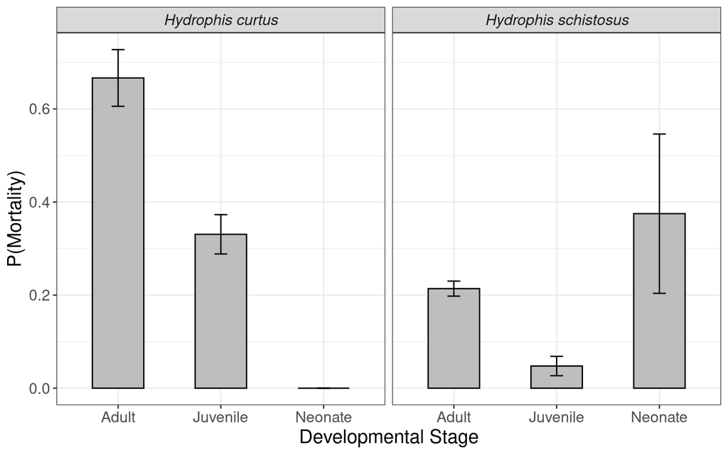

```r
dev = data.frame(Class = c("Adult", "Juvenile", "Neonate"))

snakes%>%
  filter(!is.na(Class),
         Condition.at.encounter..D.A. %in% c("Dead", "Alive"))%>% # removing missing data
  select(Species, Class, Condition.at.encounter..D.A.)%>%
  mutate(Condition = factor(Condition.at.encounter..D.A., levels = c("Alive", "Dead")))%>%
  group_by(Species)%>%
  nest()%>%
  mutate(mod = map(data, ~glm(Condition ~ Class, family = "binomial", data = .)),
         fit = map(mod, ~predict(., dev, se.fit = T, type = "response")),
         fit = map(fit, ~data.frame(.)))%>%
  select(fit)%>%
  unnest(fit)%>%
  mutate(Class = factor(c("Adult", "Juvenile", "Neonate")))%>%
  ggplot(aes(Class, fit))+
  #geom_pointrange(aes(ymin = fit - se.fit*1.96, ymax = fit + se.fit*1.96))+
  geom_col(width = 0.5, col = "black", fill = "grey")+
  geom_errorbar(aes(ymin = fit - se.fit, ymax = fit + se.fit), width = 0.125)+
  labs(y = "P(Mortality)", x = "Developmental Stage")+
  facet_wrap(~Species)+
  theme(strip.text = element_text(face = "italic"))
```

```r
ggsave(last_plot(), filename = "Figures/figure4.tiff", height = 4.5, width = 8)
```

## Mortality rate by sex

```r
snakes%>%
  filter(Sex != "")%>%
  group_by(Species, Sex)%>%
  count(Condition.at.encounter..D.A.)%>%
  # Calculating mortality rate
  mutate(N = sum(n),
         prop.dead = n/N,
         sd = sqrt(prop.dead*(1-prop.dead)/N))%>%
  filter(Condition.at.encounter..D.A. == "Dead")%>%
  select(-Condition.at.encounter..D.A.)
```

| Species | Sex | n | N | prop.dead | sd |
| --- | --- | --- | --- | --- | --- |
| Hydrophis curtus | Female | 36 | 102 | 0.3529412 | 0.0473176 |
| Hydrophis curtus | Male | 52 | 110 | 0.4727273 | 0.0476022 |
| Hydrophis schistosus | Female | 62 | 304 | 0.2039474 | 0.0231096 |
| Hydrophis schistosus | Male | 72 | 314 | 0.2292994 | 0.0237235 |

### Testing difference in mortality rates across sexes withing species

Logistic model:

```r
snakes%>%
  filter(Sex %in% c("Male", "Female"),
         Condition.at.encounter..D.A. %in% c("Dead", "Alive"))%>% # removing missing data
  select(Species, Sex, Condition.at.encounter..D.A.)%>%
  mutate(Condition = factor(Condition.at.encounter..D.A., levels = c("Alive", "Dead")))%>%
  group_by(Species)%>%
  nest()%>%
  mutate(test = map(data, ~glm(Condition ~ Sex, family = "binomial", data = .)),
         sumr = map(test, ~broom::tidy(.)),
         stat = map(test, broom::glance),
         r2 = map(test, ~mcfadden(.)))%>%
  select(sumr, stat, r2)%>%
  unnest()%>%
  select(term:p.value, df.residual, r2)
```

| Species | term | estimate | std.error | statistic | p.value | df.residual | r2 |
| --- | --- | --- | --- | --- | --- | --- | --- |
| Hydrophis schistosus | (Intercept) | -1.3535045 | 0.1424629 | -9.5007493 | 0.0000000 | 613 | 0.0008565 |
| Hydrophis schistosus | SexMale | 0.1453737 | 0.1957905 | 0.7424963 | 0.4577867 | 613 | 0.0008565 |
| Hydrophis curtus | (Intercept) | -0.6061358 | 0.2071938 | -2.9254529 | 0.0034396 | 207 | 0.0133815 |
| Hydrophis curtus | SexMale | 0.5500463 | 0.2834464 | 1.9405655 | 0.0523110 | 207 | 0.0133815 |

Fitted probability of mortality across sexes:

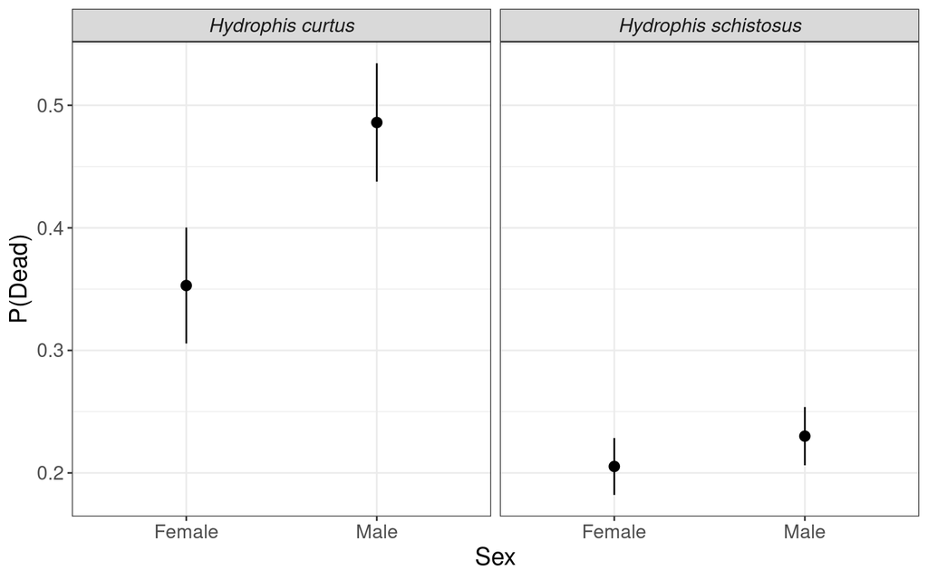

```r
sex = data.frame(Sex = c("Male", "Female"))

snakes%>%
  filter(Sex %in% c("Male", "Female"),
         Condition.at.encounter..D.A. %in% c("Dead", "Alive"))%>% # removing missing data
  select(Species, Sex, Condition.at.encounter..D.A.)%>%
  mutate(Condition = factor(Condition.at.encounter..D.A., levels = c("Alive", "Dead")))%>%
  group_by(Species)%>%
  nest()%>%
  mutate(mod = map(data, ~glm(Condition ~ Sex, family = "binomial", data = .)),
         fit = map(mod, ~predict(., sex, se.fit = T, type = "response")),
         fit = map(fit, ~data.frame(.)))%>%
  select(fit)%>%
  unnest(fit)%>%
  mutate(Sex = c("Male", "Female"))%>%
  ggplot(aes(Sex, fit))+
  geom_pointrange(aes(ymin = fit - se.fit, ymax = fit + se.fit))+
  labs(y = "P(Dead)")+
  facet_wrap(~Species)+
  theme(strip.text = element_text(face = "italic"))
```

There was no difference in mortality rates across sexes in either species.

## Mortality and female reproductive status

Are gravid females more susceptible to bycatch mortality than the rest of our sample?

```r
HS%>%
  filter(Sex == "Female",
         Class == "Adult")%>%
  group_by(Gravid)%>%
  count(Condition.at.encounter..D.A.)%>%
  # Calculating mortality rate
  mutate(N = sum(n),
         prop.dead = n/N,
         sd = sqrt(prop.dead*(1-prop.dead)/N))%>%
  filter(Condition.at.encounter..D.A. == "Dead")%>%
  select(-Condition.at.encounter..D.A.)
```

| Gravid | n | N | prop.dead | sd |
| --- | --- | --- | --- | --- |
|  | 41 | 151 | 0.2715232 | 0.0361929 |
| Yes | 16 | 85 | 0.1882353 | 0.0423991 |

### Testing thing difference in mortality rate of *H. schistosus* females by reproductive state

Logistic model:

```r
HS%>%
  filter(Sex == "Female",
         Class == "Adult",
         Condition.at.encounter..D.A. %in% c("Dead", "Alive"))%>% # removing missing data
  select(Gravid, Condition.at.encounter..D.A.)%>%
  mutate(Condition = factor(Condition.at.encounter..D.A., levels = c("Alive", "Dead")),
         Gravid = ifelse(Gravid == "", "No", Gravid))%>%
  nest()%>%
  mutate(test = map(data, ~glm(Condition ~ Gravid, family = "binomial", data = .)),
         sumr = map(test, ~broom::tidy(.)),
         stat = map(test, broom::glance),
         r2 = map(test, ~mcfadden(.)))%>%
  select(sumr, stat, r2)%>%
  unnest()%>%
  select(term:p.value, df.residual, r2)
```

| term | estimate | std.error | statistic | p.value | df.residual | r2 |
| --- | --- | --- | --- | --- | --- | --- |
| (Intercept) | -0.9685592 | 0.1834379 | -5.280039 | 0.0000001 | 232 | 0.0087809 |
| GravidYes | -0.4929586 | 0.3326292 | -1.482006 | 0.1383386 | 232 | 0.0087809 |

Fitted probability of mortality by reproductive state:

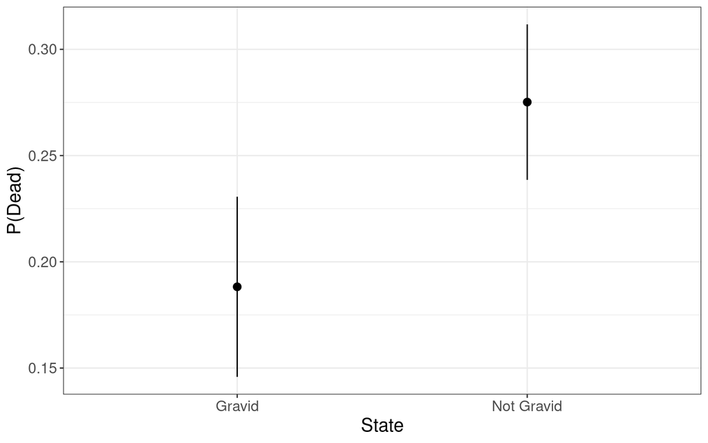

```r
gravid = data.frame(Gravid = c("Yes", "No"))

HS%>%
  filter(Sex == "Female",
         Class == "Adult",
         Condition.at.encounter..D.A. %in% c("Dead", "Alive"))%>% # removing missing data
  select(Gravid, Condition.at.encounter..D.A.)%>%
  mutate(Condition = factor(Condition.at.encounter..D.A., levels = c("Alive", "Dead")),
         Gravid = ifelse(Gravid == "", "No", Gravid))%>%
  nest()%>%
  mutate(mod = map(data, ~glm(Condition ~ Gravid, family = "binomial", data = .)),
         fit = map(mod, ~predict(., gravid, se.fit = T, type = "response")),
         fit = map(fit, ~data.frame(.)))%>%
  select(fit)%>%
  unnest(fit)%>%
  mutate(State = c("Gravid", "Not Gravid"))%>%
  ggplot(aes(State, fit))+
  geom_pointrange(aes(ymin = fit - se.fit, ymax = fit + se.fit))+
  labs(y = "P(Dead)")+
  theme(strip.text = element_text(face = "italic"))
```

# Observed reproductive cycle of *H. schistosus*

## Proportion of gravid females in the sample

```r
# percentage of gravid females in sample

HS%>%
  count(Gravid)%>%
  mutate(N = sum(n))%>%
  mutate(prop.gravid = n/N,
         sd = sqrt(prop.gravid*(1-prop.gravid)))%>%
  filter(Gravid == "Yes")%>%
  select(-c(Gravid))
```

| n | N | prop.gravid | sd |
| --- | --- | --- | --- |
| 88 | 967 | 0.0910031 | 0.2876135 |

## Number of gravid females encountered per year

```r
# checking the number of gravid females per year

HS%>%
  group_by(Year)%>%
  filter(Gravid == "Yes")%>%
  count(Gravid)%>%
  spread(Gravid, n)%>%
  rename(`n(Gravid Females)` = Yes)
```

| Year | n(Gravid Females) |
| --- | --- |
| 2016 | 1 |
| 2018 | 75 |
| 2019 | 12 |

## Monthly variation in proportion of gravid females

Proper sampling was only conducted in 2018/19 and hence only this period is used for analysis of reproductive cycles.

```r
# calculating the proportion of gravid females per month

gravid <- HS%>%
  mutate(Month = factor(Month, levels = month.name))%>%
  filter(Year == "2018" | Year == "2019")%>% # only for 2018/19
  group_by(Month)%>%
  summarise(N = n(),
            gravid = sum(Gravid == "Yes"),
            prop.gravid = gravid/N,
         sd = sqrt(prop.gravid*(1-prop.gravid)/N))

gravid
```

| Month | N | gravid | prop.gravid | sd |
| --- | --- | --- | --- | --- |
| January | 102 | 12 | 0.1176471 | 0.0319015 |
| February | 134 | 34 | 0.2537313 | 0.0375909 |
| March | 129 | 24 | 0.1860465 | 0.0342622 |
| April | 54 | 7 | 0.1296296 | 0.0457096 |
| May | 36 | 1 | 0.0277778 | 0.0273893 |
| October | 16 | 0 | 0.0000000 | 0.0000000 |
| November | 69 | 3 | 0.0434783 | 0.0245504 |
| December | 34 | 6 | 0.1764706 | 0.0653787 |

Describing change in the relative proportions of gravid females across months and years of sampling.

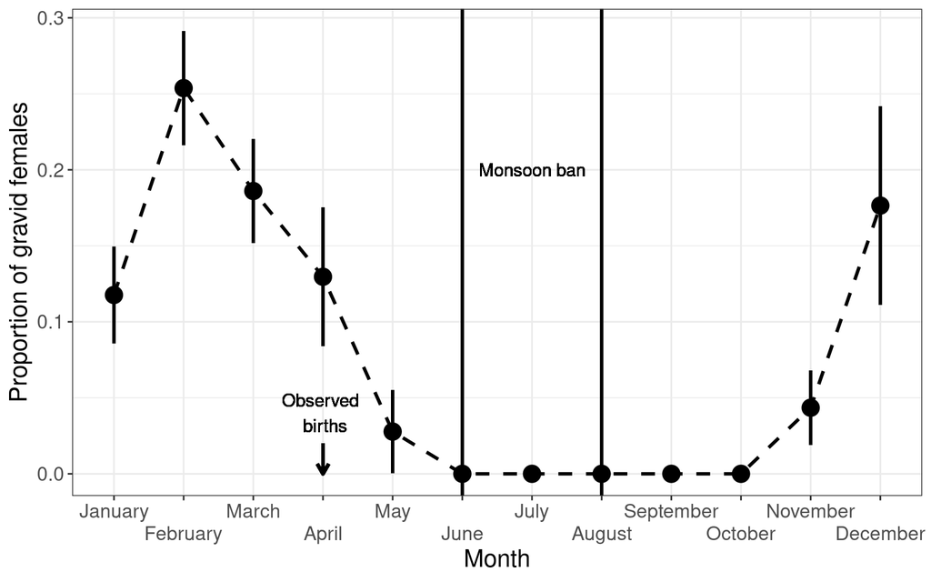

```r
# plotting prop gravid per month

gravid%>%
  mutate(Month = factor(Month, levels = month.name))%>%
  complete(Month, fill = list(prop.gravid = 0))%>%
  ggplot(aes(Month, prop.gravid))+
  geom_pointrange(size = 1, aes(ymin = prop.gravid + sd, ymax = prop.gravid - sd))+
  geom_path(aes(group = 1), size = 1, linetype = "dashed")+
  geom_segment(aes(x = "April", xend = "April", y = 0 , yend = 0.02), #marking births
               arrow = arrow(length = unit(0.25, "cm"), ends = "first"), size = 1)+
  geom_text(aes(x = "April", y = 0.04, label = paste("Observed \n births")))+
  geom_vline(aes(xintercept = "June"), size = 1)+#start of the monsoon ban
  geom_vline(aes(xintercept = "August"), size = 1)+#end of the monsoon ban
  geom_text(aes(x = "July", y = 0.20, label = "Monsoon ban"))+
  scale_x_discrete(guide = guide_axis(n.dodge = 2))+
  labs(y = "Proportion of gravid females")
```

Pregnancy from Novemeber to May. Peak in Feb. Observed two live births in April.

# Development of embryos and eggs

## Sample size

```r
embryos%>%
  summarise(n.mothers = length(unique(Field.Code)),
            n.embryos = length(unique(Embryo.Code)))
```

| n.mothers | n.embryos |
| --- | --- |
| 29 | 235 |

## Summary statistics of egg measurements

```r
embryos%>%
  select(Egg.Length..mm.., Egg.Width..mm.., Egg.Weigth..g.., Snout.to.Vent..cm., Embryo.Weight..g.)%>%
  skimr::skim()%>%
  skimr::yank("numeric")%>%
  select(c(skim_variable, mean, sd))
```

**Variable type: numeric**

| skim_variable | mean | sd |
| --- | --- | --- |
| Egg.Length..mm.. | 39.71 | 11.72 |
| Egg.Width..mm.. | 32.23 | 9.01 |
| Egg.Weigth..g.. | 14.30 | 5.45 |
| Snout.to.Vent..cm. | 17.72 | 5.24 |
| Embryo.Weight..g. | 4.83 | 6.28 |

## Sex ratios within clutches

```r
embryos%>%
  filter(Sex != "")%>%
  summarise(prop.female = sum(Sex == "Female")/n(),
            sd = sqrt(prop.female*(1-prop.female)/n()))
```

| prop.female | sd |
| --- | --- |
| 0.5180723 | 0.0387822 |

### Number of feamle embryos

```r
embryos%>%
  filter(Sex != "")%>%
  summarise(females = sum(Sex == "Female"),
            N = n())
```

| females | N |
| --- | --- |
| 86 | 166 |

### Testing clutch sex ratio

```r
broom::tidy(prop.test(86, 166, p = 0.5))%>% # Z - test
  select(estimate:conf.high)
```

| estimate | statistic | p.value | parameter | conf.low | conf.high |
| --- | --- | --- | --- | --- | --- |
| 0.5180723 | 0.1506024 | 0.6979603 | 1 | 0.4395567 | 0.5957383 |

The sex ratio in clutches is not significantly different from 0.5.

## Infertility rate

Percentage of eggs with no embryos present:

```r
embryos%>%
  count(Embryo)%>%
  mutate(N = sum(n), rate = n/N, sd = sqrt(rate*(1-rate)/N))%>%
  select(-N)
```

| Embryo | n | rate | sd |
| --- | --- | --- | --- |
| Absent | 5 | 0.0212766 | 0.0094134 |
| Present | 230 | 0.9787234 | 0.0094134 |

## Matrotrophy

Do female *H. schistosus* expend energy in the development of embryos? or Are the eggs formed and yolk only provides nourishment?

### Change in yolk weight with embryo weight

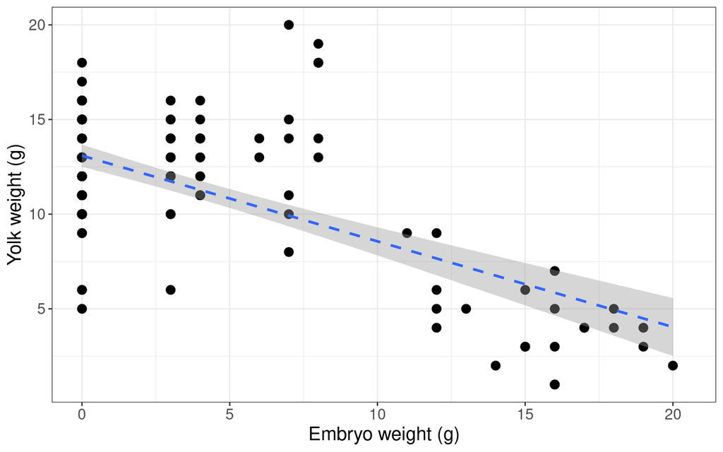

```r
embryos%>%
  ggplot(aes(Embryo.Weight..g., Yolk.Weight..g.))+
  geom_point(size = 3)+
  geom_smooth(method = "lm", linetype = "dashed", size = 1)+
  labs(x = "Embryo weight (g)", y = "Yolk weight (g)")
```

**Linear model to test change in yolk weight with embryo development:**

```r
embryos%>%
  select(Yolk.Weight..g., Embryo.Weight..g.)%>%
  nest()%>%
  # Yolk weight is normally distributed
  mutate(mod = map(data, ~lm(Yolk.Weight..g. ~ Embryo.Weight..g., data = .)),
         sumr = map(mod, broom::tidy),
         stat = map(mod, broom::glance))%>%
  select(sumr, stat)%>%
  unnest()%>%
  select(term:r.squared, df.residual)
```

| term | estimate | std.error | statistic | p.value | r.squared | df.residual |
| --- | --- | --- | --- | --- | --- | --- |
| (Intercept) | 13.0905565 | 0.2965229 | 44.14687 | 0 | 0.4071222 | 147 |
| Embryo.Weight..g. | -0.4526283 | 0.0450509 | -10.04705 | 0 | 0.4071222 | 147 |

Yolk weight decreases by 0.45 g for every 1g increase in embryo weight.

### Change in egg mass with embryo development

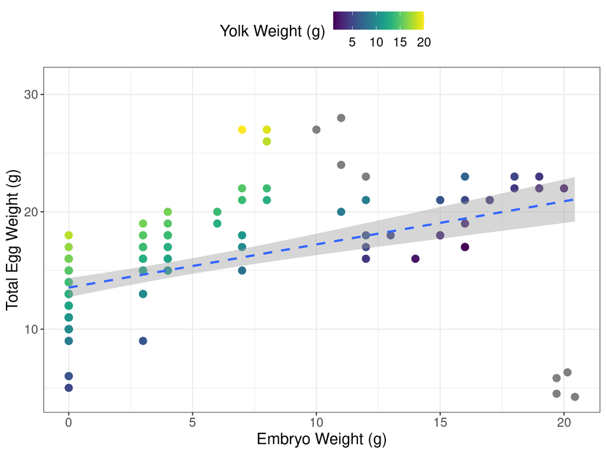

```r
embryos%>%
  ggplot(aes(Embryo.Weight..g., Egg.Weigth..g..))+
  geom_point(aes(col = Yolk.Weight..g.), size = 3)+
  geom_smooth(method = "lm", linetype = "dashed", size = 1)+
  scale_color_viridis(name = "Yolk Weight (g)")+
  labs(x = "Embryo Weight (g)", y = "Total Egg Weight (g)")
```

Linear model to test relation ship between total egg mass and embryo development:

```r
embryos%>%
  select(Egg.Weigth..g.., Embryo.Weight..g.)%>%
  nest()%>%
  # Total egg mass is normally distributed
  mutate(mod = map(data, ~lm(Egg.Weigth..g.. ~ Embryo.Weight..g., data = .)),
         sumr = map(mod, broom::tidy),
         stat = map(mod, broom::glance))%>%
  select(sumr, stat)%>%
  unnest()%>%
  select(term:r.squared, df.residual)
```

| term | estimate | std.error | statistic | p.value | r.squared | df.residual |
| --- | --- | --- | --- | --- | --- | --- |
| (Intercept) | 13.5441434 | 0.4114909 | 32.91481 | 0 | 0.2188866 | 155 |
| Embryo.Weight..g. | 0.3676922 | 0.0557912 | 6.59050 | 0 | 0.2188866 | 155 |

Total egg mass increases by 0.36 g for every 1g increase in embryo weight.

Note: Embryo weight is log-normally distributed.

# Reproductive effort

Does the amount of enery expended by female *H. schistosus* reduce with age?

```r
# Cleaning reproductive effort data

re <- embryos%>%
  left_join(snakes, by = c("Date", "Field.Code", "Species"))%>%
  select(Date, Field.Code, Embryo.Code, Species, Egg.Length..mm..:Tail.Length..cm..x,
         Egg.Weigth..g..:Sex.x, Snout.to.Vent..cm..y:Tail.Length..cm..y, Weight..g.,
         -Body.Length..cm..x, - Body.Length..cm..y)%>%
  filter(Species == "Hydrophis schistosus")%>%
  rename(Embryo.SVL = Snout.to.Vent..cm..x,
         Embryo.TL = Tail.Length..cm..x,
         Embryo.Sex = Sex.x,
         Female.SVL = Snout.to.Vent..cm..y,
         Female.TL = Tail.Length..cm..y,
         Mother.Wt = Weight..g.
         )%>%
  # Removing erroneous data point
  filter(Female.SVL > 50)
```

## Increase in clutch size with female age

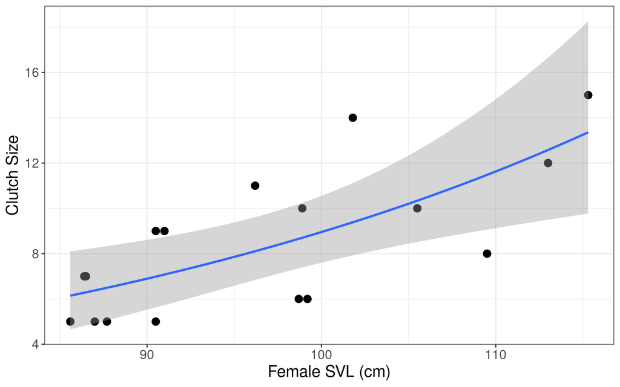

```r
re_clutch <- re%>%
  select(Field.Code, Egg.Weigth..g.., Mother.Wt, Female.SVL, Embryo.SVL)%>%
  group_by(Field.Code)%>%
  summarise(clutch.size = n(),
            Clutch.wt = sum(Egg.Weigth..g.., na.rm = T),
            Mother.wt = last(Mother.Wt),
            Female.SVL = last(Female.SVL),
            Embryo.SVL = median(Embryo.SVL, na.rm = T))%>%
  mutate(rcm = Clutch.wt/(Mother.wt - Clutch.wt))%>%
  filter(rcm > 0)%>% # removing missing data
  replace_na(replace = list(Embryo.SVL = 3)) # filling small embryos svl

re_clutch%>%
  ggplot(aes(Female.SVL, clutch.size))+
  geom_point(size =3)+
  geom_smooth(method = 'glm', method.args = list(family = 'poisson'))+
  labs(x = "Female SVL (cm)", y = "Clutch Size")
```

**Generalised linear model to test change in clutch size with female SVL:**

Clutch size is poisson distributed with mean 8.4705882 and variance 10.1397059

```r
re_clutch%>%
  select(Female.SVL, clutch.size)%>%
  nest()%>%
  mutate(mod = map(data, ~glm(clutch.size ~ Female.SVL, data = ., family = "poisson")),
         sumr = map(mod, broom::tidy),
         stat = map(mod, broom::glance),
         r.squared =  map_dbl(stat, ~mcfadden(.)))%>%
  select(sumr, stat,r.squared)%>%
  unnest()%>%
  select(c(term:p.value, r.squared, df.residual))
```

| term | estimate | std.error | statistic | p.value | r.squared | df.residual |
| --- | --- | --- | --- | --- | --- | --- |
| (Intercept) | -0.4217080 | 0.8376185 | -0.5034607 | 0.6146404 | 0.5082829 | 15 |
| Female.SVL | 0.0261386 | 0.0084081 | 3.1087208 | 0.0018790 | 0.5082829 | 15 |

## Change in overall reproductive effort with age

**Beta regression to determine relationship between relative clutch mass and female SVL:**

```r
require(betareg)

re_clutch%>%
  select(Female.SVL, Embryo.SVL, rcm)%>%
  nest()%>%
  mutate(mod = map(data, ~betareg(rcm ~ Female.SVL + Embryo.SVL, data = .)),
         sumr = map(mod, ~tidy(.)),
         stat = map(mod, broom::glance))%>%
  select(sumr, stat)%>%
  unnest()%>%
  select(component:pseudo.r.squared, df.residual)
```

| component | term | estimate | std.error | statistic | p.value | pseudo.r.squared | df.residual |
| --- | --- | --- | --- | --- | --- | --- | --- |
| mean | (Intercept) | -0.8772327 | 1.0848699 | -0.8086064 | 0.4187416 | 0.5479393 | 13 |
| mean | Female.SVL | -0.0055914 | 0.0106770 | -0.5236825 | 0.6004994 | 0.5479393 | 13 |
| mean | Embryo.SVL | 0.0478256 | 0.0121246 | 3.9445140 | 0.0000800 | 0.5479393 | 13 |
| precision | (phi) | 29.8202783 | 10.0920099 | 2.9548404 | 0.0031283 | 0.5479393 | 13 |

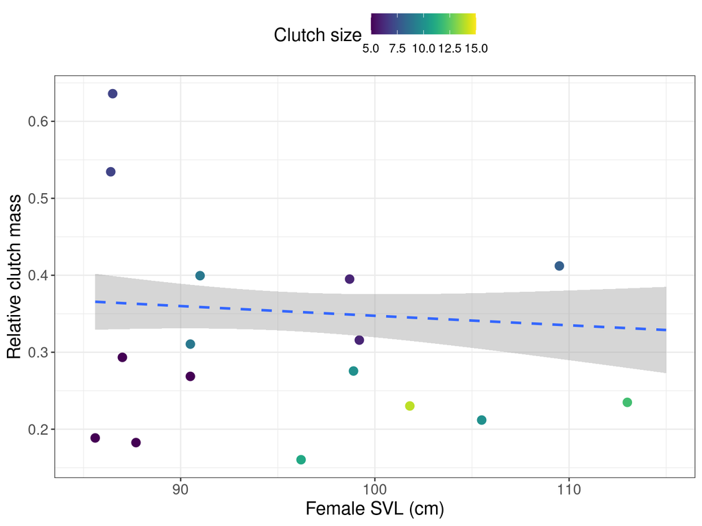

```r
# Predicting for plotting fit
require(gam)
require(mgcv)

re_mod <- gam(rcm ~ Female.SVL + Embryo.SVL, family = betar(link = "logit"), data = re_clutch)

re_simdata <- data.frame(Female.SVL = seq(min(re_clutch$Female.SVL), max(re_clutch$Female.SVL), 0.1),
                         Embryo.SVL = median(re$Embryo.SVL, na.rm = T))

re_pred <- predict(re_mod, newdata = re_simdata, "response", se.fit = T)

re_simdata <- enframe(re_pred)%>%
  spread(name, value)%>%
  unnest()%>%
  mutate(Female.SVL = re_simdata$Female.SVL,
         Embryo.SVL = re_simdata$Embryo.SVL)

# Plotting

re_clutch%>%
  ggplot(aes(Female.SVL, rcm))+
  geom_point(aes(col = clutch.size), size = 3)+
  geom_smooth(data = re_simdata, aes(y = fit, ymin = fit - se.fit, ymax = fit + se.fit), stat = "identity", linetype = "dashed")+
  scale_y_continuous(name = "Relative clutch mass")+
  scale_x_continuous(limits = c(85, 115), name = "Female SVL (cm)")+
  scale_color_viridis(name = "Clutch size")+
  theme(legend.text = element_text(size = 10))
```

The overall reproductive effort **does not change** with female age.

## Change in reproductive effort per embryo with female age

Does the effort per embryo change with female age?

```r
# calculating reproductive effort per embruo

re_embryo <- re%>%
  select(Field.Code, Embryo.Code, Egg.Weigth..g..,  Mother.Wt, Female.SVL, Embryo.Sex, Embryo.SVL)%>%
  group_by(Field.Code)%>%
  mutate(clutch.wt = sum(Egg.Weigth..g..),
         Female.wt = Mother.Wt - clutch.wt)%>%
  group_by(Field.Code, Embryo.Code)%>%
  summarise(inv = Egg.Weigth..g../Female.wt,# investment per embryo
            Female.SVL = last(Female.SVL),
            Embryo.Sex = Embryo.Sex,
            Embryo.SVL = Embryo.SVL)%>%
  ungroup()
```

**Linear model to determine relationship between female SVL and investment per embryo:**

We have controlled for the effect of embryo development.

```r
re_embryo%>%
  select(Female.SVL, inv, Embryo.SVL)%>%
  nest()%>%
  mutate(mod = map(data, ~betareg(inv ~ Female.SVL + Embryo.SVL, data = .)),
         sumr = map(mod, broom::tidy),
         stat = map(mod, broom::glance))%>%
  select(sumr,stat)%>%
  unnest()%>%
  select(component:p.value, pseudo.r.squared, df.residual)
```

| component | term | estimate | std.error | statistic | p.value | pseudo.r.squared | df.residual |
| --- | --- | --- | --- | --- | --- | --- | --- |
| mean | (Intercept) | -2.2798667 | 0.4894683 | -4.657843 | 0.0000032 | 0.5627972 | 54 |
| mean | Female.SVL | -0.0161182 | 0.0050085 | -3.218169 | 0.0012901 | 0.5627972 | 54 |
| mean | Embryo.SVL | 0.0491682 | 0.0077622 | 6.334311 | 0.0000000 | 0.5627972 | 54 |
| precision | (phi) | 233.3499725 | 43.5079611 | 5.363386 | 0.0000001 | 0.5627972 | 54 |

Plotting relatonship between residuals and female SVL:

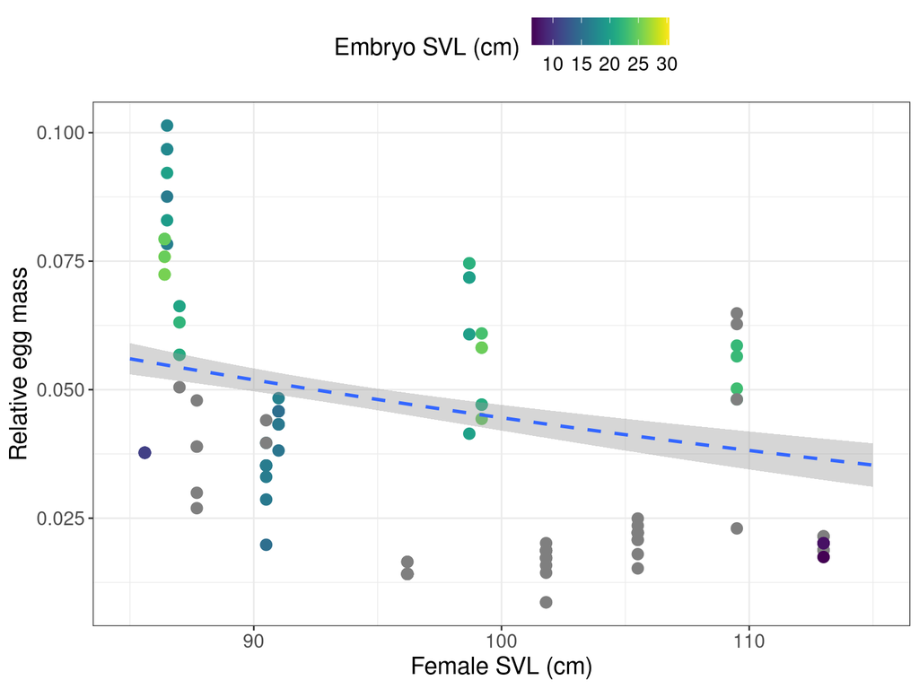

```r
# using residuals to control for embryo development

emsvlinv <- gam(inv ~ Female.SVL + Embryo.SVL, family = betar(link = "logit"), data = re_embryo)

inv_simdata <- data.frame(Female.SVL = seq(min(re_embryo$Female.SVL), max(re_embryo$Female.SVL), 0.1),
                          Embryo.SVL = median(re_embryo$Embryo.SVL, na.rm = T))%>%
  nest()%>%
  mutate(sim = map(data, ~predict(object = emsvlinv, newdata = ., type = "response", se.fit = T)),
         sim = map(sim, ~data.frame(.)))%>%
  unnest()

# Plotting

re_embryo%>%
  ggplot(aes(Female.SVL, inv))+
  geom_point(aes(col = Embryo.SVL), size = 3)+
  geom_smooth(data = inv_simdata, aes(y = fit, ymin = fit -se.fit, ymax = fit+se.fit),stat = "identity", linetype = "dashed", size = 1)+
  scale_y_continuous(name = "Relative egg mass")+
  scale_x_continuous(limits = c(85, 115), name = "Female SVL (cm)")+
  scale_color_viridis(name = "Embryo SVL (cm)")
```

The relative egg mass (controlled for embryo development) reduces with female SVL.

## Difference in reproductive effort for male and female embryos

Does female investment differ by sex of the embryo?

**Linear model to test for the difference in female investment by embryo sex:**

We controlled for the effect of embryo development.

```r
re_embryo%>%
  filter(Embryo.Sex == "Male" | Embryo.Sex == "Female")%>%
  select(Embryo.Sex, inv, Embryo.SVL)%>%
  nest()%>%
  mutate(mod = map(data, ~betareg(inv ~ Embryo.Sex + Embryo.SVL, data = .)),
         sumr = map(mod, broom::tidy),
         stat = map(mod, broom::glance))%>%
  select(sumr, stat)%>%
  unnest()%>%
  select(component:p.value, pseudo.r.squared, df.residual)
```

| component | term | estimate | std.error | statistic | p.value | pseudo.r.squared | df.residual |
| --- | --- | --- | --- | --- | --- | --- | --- |
| mean | (Intercept) | -3.7036341 | 0.1763377 | -21.003076 | 0.0000000 | 0.4781387 | 54 |
| mean | Embryo.SexMale | -0.1376065 | 0.0839749 | -1.638663 | 0.1012835 | 0.4781387 | 54 |
| mean | Embryo.SVL | 0.0481588 | 0.0083489 | 5.768291 | 0.0000000 | 0.4781387 | 54 |
| precision | (phi) | 205.9146533 | 38.4135707 | 5.360466 | 0.0000001 | 0.4781387 | 54 |

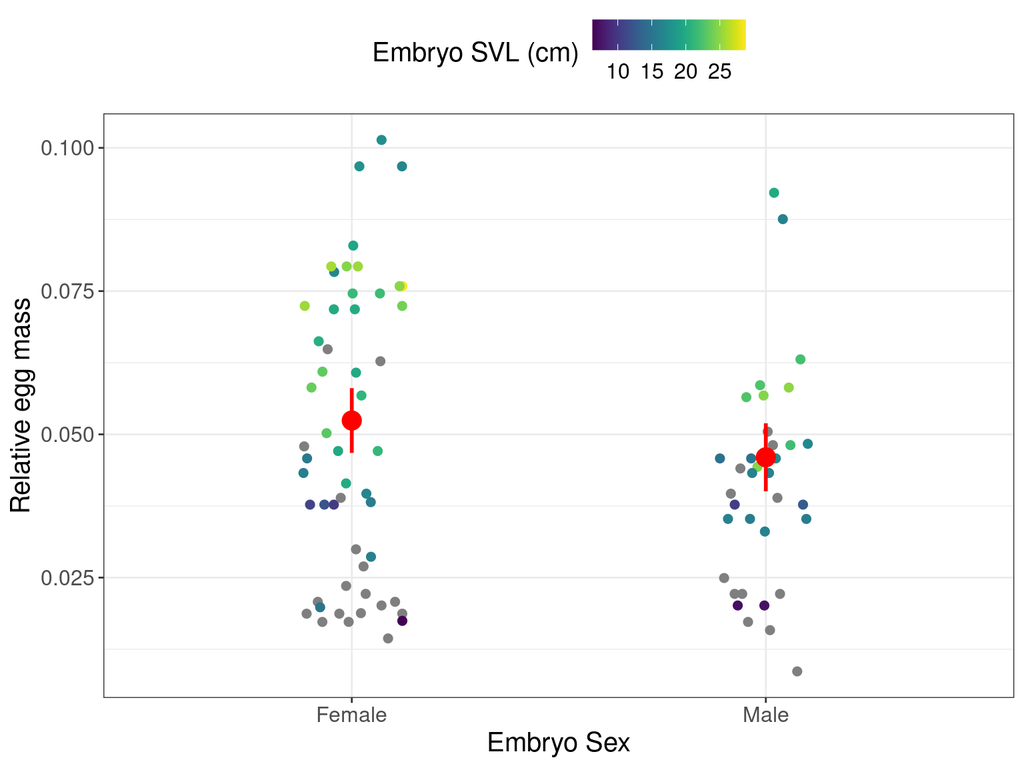

```r
# Simulating data to plot model fit

inv_sex_mod <- gam(inv ~ Embryo.Sex + Embryo.SVL, family = betar(link = "logit"), data = re_embryo)

inv_sex_simdata <- data.frame(Embryo.Sex = c("Male", "Female"),
                              Embryo.SVL = median(re_embryo$Embryo.SVL, na.rm = T))%>%
  nest()%>%
  mutate(sim = map(data, ~predict(inv_sex_mod, newdata = ., type = "response", se.fit = T)),
         sim = map(data, ~data.frame(sim)))%>%
  unnest()

re_embryo%>%
  filter(Embryo.Sex == "Male" | Embryo.Sex == "Female")%>%
  ggplot(aes(Embryo.Sex, inv))+
  geom_jitter(aes(col = Embryo.SVL), size = 2, width = 0.125)+
  geom_pointrange(data = inv_sex_simdata, aes(y = fit, ymin = fit -(se.fit*1.96), ymax = fit+(se.fit*1.96)), size = 1, col = "red")+
  scale_y_continuous(name = "Relative egg mass")+
  scale_x_discrete(name = "Embryo Sex")+
  scale_color_viridis(name = "Embryo SVL (cm)")
```

Female investment does not differ significantly with embryo sex.